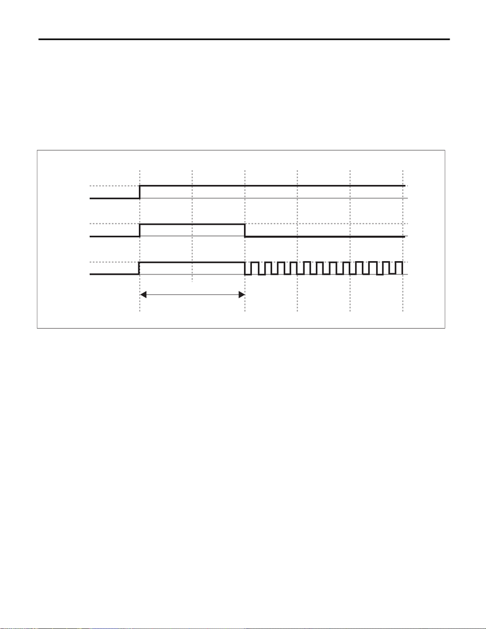

CVT(diag)-28

AWD Warning Light Display

CONTINUOUSLY VARIABLE TRANSMISSION (DIAGNOSTICS)

14.AWD Warning Light Display

A: OPERATION

AWD light blinks when a fault occurs in AWD.

• At normal condition

After turning the ignition switch to ON, illuminates for 2 seconds then goes off.

• When malfunction is detected

1. When tire with different diameter is installed.

2. When air pressure of any of four tires is excessively low.

If the AWD light does not illuminate, or illumination patterns are not as above, check the AWD light circuit.

<Ref. to CVT(diag)-29, INSPECTION, AWD Warning Light Display.>

(A) Ignition switch condition

(1) At normal condition (2) When malfunction is detected

CVT00593

(1)

OFF

ON

(2)

(A)

OFF

OFF

2 sec.

Illuminate

Illuminate

[figure not shown]

CVT(diag)-29

AWD Warning Light Display

CONTINUOUSLY VARIABLE TRANSMISSION (DIAGNOSTICS)

B: INSPECTION

DIAGNOSIS:

• CAN communication is lost with the combination meter.

• Combination meter malfunction

TROUBLE SYMPTOM:

• When the ignition switch is turned to ON, the AWD light does not illuminate.

• AWD light remains lit after engine start.

• AWD light is blinking immediately after engine start.

Step Check Yes No

1 CHECK DTC.

Read the DTC relating the TCM using the Sub-

aru Select Monitor.

Is DTC U0155 or U0423 dis-

played?

Perform the self-

diagnosis of com-

bination meter.

Go to step 2.

2 CHECK DTC.

Read the DTC relating the TCM using the Sub-

aru Select Monitor.

Are DTCs other than U0155

and U0423 displayed?

Perform the diag-

nosis according to

DTC.

Go to step 3.

3 CHECK COMBINATION METER.

Read DTC of combination meter.

Is DTC displayed? Perform the diag-

nosis according to

DTC.

Go to step 4.

4 CHECK AWD LIGHT.

Turn the ignition switch to ON.

Does AWD light illuminate and

then go off in 2 seconds?

Go to step 5. Perform the self-

diagnosis of com-

bination meter.

<Ref. to IDI-6,

SELF-DIAGNO-

SIS DISPLAY

MODE, OPERA-

TION, Combina-

tion Meter

System.>

5 CHECK AWD LIGHT.

Start the engine.

Does the AWD light go off? Current condition

is normal. Go back

to Basic Diagnostic

Procedure. <Ref.

to CVT(diag)-2,

Basic Diagnostic

Procedure.>

Go to step 6.

6 CHECK DTC.

Read the DTC relating the TCM using the Sub-

aru Select Monitor.

Is DTC displayed? Perform the diag-

nosis according to

DTC.

Go to step 7.

7 CHECK COMBINATION METER.

Perform the self-diagnosis of combination

meter. <Ref. to IDI-6, SELF-DIAGNOSIS DIS-

PLAY MODE, OPERATION, Combination

Meter System.>

Is there any trouble with the

combination meter?

Repair the combi-

nation meter.

Replace the TCM.

<Ref. to

CVT(TR690)-126,

Transmission Con-

trol Module

(TCM).>